# Grade 7 Maths

## Exponents and Powers

### Laws of Exponents

- **Exponents with negative bases**
  - **example 1**: $-2^2$
  - $-(2*2)$
  - $-4$
  - *note*: `Order of Operation` = exponents are raised before multiplication. Thus $-2^2$ equals $-(2^2)$ which will always be negative, no matter if the exponent is odd or equal. If you want a positive result, put paranthesis around base *then* write exponent as shown below.
  - **example 2**: $(-2)^2$
  - $(-2)*(-2)$
  - $4$
  - *note*: whenever you raise a negative base by an odd exponent, you will get an negative result, because the negatives do not cancel out
    - $(neg)^ odd = neg$
- **Exponents with negative fractional bases** ** **example**: $(-2/8)^2$
  - $(-2/8)*(-2/8)$
  - $4/16$

## Algebraic Equations [tut](https://www.khanacademy.org/math/algebra/introduction-to-algebra/overview_hist_alg/v/the-beauty-of-algebra?ref=staff_video_picks)

- Useful tool for finding out stuff in real life, even if it isn’t there to count or does not exist
- Equation is a statement that helps us understand the equality between variables and constants
- Variables can be any value and are respresented by letters `a`,`b`,`x`, , etc
- Constants are fixed values. `x+3=7` 3 and 7 are constants, `x` variable
- one side of the equation is equal to the other. To find out the mystery value `x`, we do the same things to both sides to keep the scales balanced
- **example**: You have three pokeballs which cost $9. How much do they cost each?
  - write as equation: 3P = $9
  - 1. Keep the scales balanced by doing the same to each side
  - Let’s try getting P on it’s own so we’re only left with 1/3rd, aka one Pokeball.
  - Multiply by 1/3 or divide by 3
  - $3P/3 = $9/3$
  - $P = $3$

### Introduction to Algebra

#### Combining Like terms

To make life easier we combine like-terms to make the expression simpler, like how you might combine pens in one box and pencils in another to make organising your room simpler!

### Quadratics

- **Factoring simple expressions** = put expression into lowest terms and make it easier to answer
- Factoring Linear Binomials
  - `Binomial` = sum of two terms. `linear` = expression with no exponents or square roots
  - **example**
  - $4x+18$
  - Find greatest common factor and multiply out
  - $2(2x) + 2(9)$
  - $2(2x+9)$

### Algebra Glossary

- $2x+3x +5$. x = variable, 2 & 3 = coefficients, 5 = constant, 2x & 3x = like terms.
- **constant** = a regular number that is without a variable
- **coefficients** = regular/constant number thats multiplied by the variable
- **variables** = The thing, normally symbolised by a letter, that you’re trying to solve.
  - i.e. `variables` = Chuck Norri, money, Pokeballs, slices of cake.
- **like terms** = terms that contain the same variable

## Proportions

Pikachu is poisoned, so we loose 5 HP for every 2 steps we take. If we have 30 HP, how many steps can we take?

## Statistics [tut1](http://mathbench.umd.edu/modules/visualization_log-transformations/page04.htm) [tut2](http://www.biostathandbook.com/transformation.html) [Rtut](http://www.r-statistics.com/2013/05/log-transformations-for-skewed-and-wide-distributions-from-practical-data-science-with-r/)

### Experimental Probabillity

- experimental probabillity = computing the probabillity of a future event based on our obs of past events
- $Experimental~Probabillity=\frac{Number~of\,favourable\,outcomes}{Total~ number~of~outcomes}$
- Chance of sun tomorrow = number of sunny days this / total number of days

### Infer estimates from random sample

Estimate = population size * sample proportion

Example: 20 Pokemoned were surveyed. 8 were grass type. What number of the total pokemon (151) are grass type?

151 * 8/20 = X of total pop that are grass type

Or…use the inverse of the percentage

20% of a sample like drugs. What number is that for the population of 80

estimate = inverse of percentage of sample * total pop

2/10 like drugs

10/2 * 80 = X of total pop who like drugs

### Compound events and sample spaces

- **Probabillity of compound event**
  - **example**: You’re at a clothing store. You get to pick from four pieces of clothing (shirt, jean, underwear, hat) and from 3 colours (blue, purple, orange). If you pick by the clothing and colour by random, what are the chances you’ll have an orange hat?
    - probabillity = favourable outcomes / total possible outcomes
    - Draw a compound space

[output not shown]

```
    * There is 12 (3*4) possible combinations in total. If we pick randomly all choices are equally likely
    * There is only one favourable outcome of an orange hat
    * $probabillity of randomly picking a orange hat = 1/12$
```

## Basic Geometry

- **History**
- Geometery involves the measurements of shapes, patterns, sizes and posistions
- Building bows, enclosing farms, building shelters, navigating/star-gazing and organising communities all required notions of center, equidistance, length, area, volume, straightness.

### Triangles

- **Triangle Inequality Theorem** any side of triangle must be less than sum of the two other sides
  - a < (b+c), b < (a+c), c < (c+b)

### Area and Perimeter

- **Use**
  - How far a wheel will travel in one revolution
  - Calculate the length of fence required to surround house
  - How much space farmland will take up
  - **note**: Splitting farmland by perimeter is a bad idea, as production is proportional to area. Having a field with a long permeter and small area = small production
  - How long you have to walk around a building
- **Interesting notes**
  - The more you cut a shape, the lesser the area but larger perimeter. This happens as the length around the shape increase, as there is more sides, but the space inside the shape decreases.
  - Coral, Kale and other marine organisims exhibit hyperbolic geometry, maximising surface area in a limited volume, providing a greater opportuninity for photosynthesisthis and filter feeding.
- **Same perimeter, different area**
  - This is important to know about when designating farmland, for example:
  - You have 24 metres of fencing. What are the different farmlands you can make with that?
  - Farmland 1 = $1*11m. P = 24. A = 11^2$
  - Farmland 2 = $2*10m. P = 24. A = 20^2$
  - Farmland 3 = $9*3m. P = 24. A = 27^2$
  - Although each farm has the same perimeter, the area changes.

#### Area and Circumfrence of Circles

- **If the circumfrence of a lake is 400m, what is the diameter?**
  - $C = pid$
  - $\pi d = C$
  - $ d = 400 pi m$
- **Impact of Radius Change on the A and C of circles**
  - circumfrence increases by the same factor
  - area increases by the factor squared

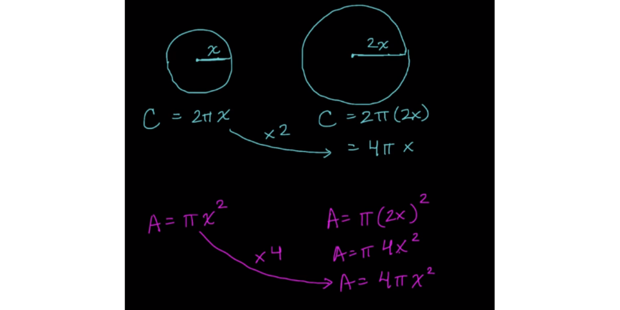

#### Scale Drawings

Peter just buried a treasure chest on a remote island and is making a map so he can find it later. One of the key landmarks in the area is a small rectangular hut, 5m by 8m.

The map’s scale is 2 units: 1m. Help him draw…

- Convert 5m into units
  - $5 ~m~ * ~2~ units / 1 m$
  - 5 m * 2 units / 1 m
  - $= 10 units$
- Convert 8m into units
  - $8m * 2 units / 1 m$
  - 8 m * 2 units / 1 m
  - $= 16 units$

## Rates and proportional relationships

[Tutorial](https://prezi.com/ilcjj9akpubx/pokemon-themed-prezi/)

- A proportional relationship is where: $\frac{Y}{X} = K$ the relationship between y and x is always going to be a constant number
  - `constant` = a number that stays the same and you multiply by to get an answer
  - `K` is also know as the **constant rate of change** or **constant rate of proportionality**
- Useful as it tells you what numbers to expect, allowing you to make predictions or fill in missing gaps
- Proportional relationships can be shown as a equation, table or graph
- **Equation Form**
- $\frac{Y}{X} = K$
- $Y=KX$
- **example**: You can catch 4 Pokemon every 8 hours. How many can you catch in 48 hours? `x` = Pokemon Caught. `y` = Hours.

| x | 4 | 8 | 12 | 16 | 20 | ? | 28 |
| --- | --- | --- | --- | --- | --- | --- | --- |
| y | 8 | 16 | 24 | 32 | 40 | 48 | 56 |

- Calculate the constant (rate of change) = 8/4 = 2.
- 48/2 = 24 pokemon!

### Visually identifying proportional relationships through graphs

- **Label a proportional relationship on a coordinate plane**
  - The above table would be written as $(4,8), (8,16), (12,24)$
- Relationships are proportional if the points can be connected by a **(1) straight line** through the **(2)origin** (0,0)

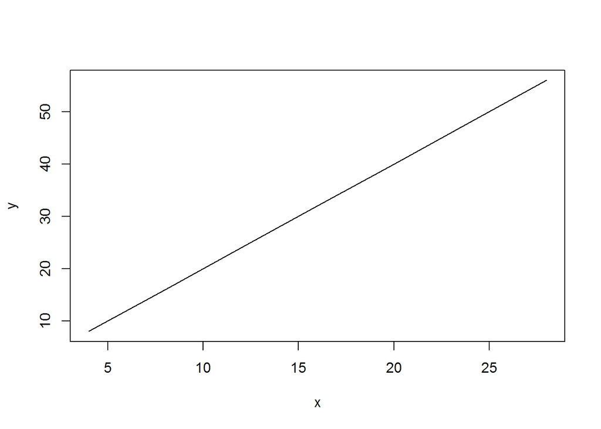

- Relationships are not proportional if there is no multiplicative constant for us to multiply by to make our coordinates go in a straight line through the origin, i.e. (12,20)

| x | 4 | 8 | 12 | 16 | 20 | ? | 28 |
| --- | --- | --- | --- | --- | --- | --- | --- |
| y | 8 | 16 | 20 | 32 | 40 | 48 | 56 |

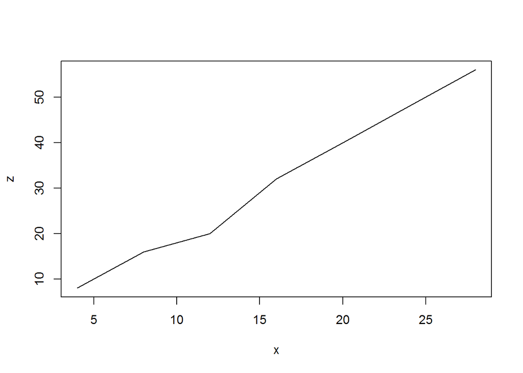

### Independent and Dependent Variables

- Dependent means that one value relies on the other
  - **example**: If you want to buy three Pokemon for $30, then the cost is dependent on the amount of Pokemon.

### Unit Rate

- Unit rate is the ratio between the values, i.e. every 8 hours I catch four Pokemon.

## Improvements

Add history to each section and uses